# Необходимая величина подогрева входного воздуха КВОУ ГТУ

Для потока воздуха к которому нет подвода/отвода теплоты (адиабатический процесс) выполняется условие: $h + w^2/2 = c_p t + w^2/2 = const$ Пусть $t_0$ - температура окружающего КВОУ воздуха при нулевой скорости воздуха (температура полного торможения). Воздух поступает в КВОУ с некоторой скоростью, которая увеличивается во входном сечении компрессора из-за уменьшения площади проходного сечения. Чем выше скорость воздуха, тем ниже статическая температура потока по сравнению с температурой полного торможения. Разница этих температур определяется по формуле $dt = - w^2/(2c_p)$.

```python
w = 250  # максимальная скорость потока на входе в компрессор, м/с
cp = 1002.4  # теплоёмкость воздуха Дж/кг/К
# Разница статической температуры воздуха в потоке на входе в компрессор и воздуха перед КВОУ, C
dt_потока = -w*w/2/cp
dt_потока  # C
```

```
-31.17517956903432
```

Непосредственно у поверхности входных элементов компрессора, которые обтекает воздух и на которых возможно образование льда, скорость воздуха в силу наличия вязкости равна нулю. Температура неподвижного воздуха должна быть равна температуре воздуха перед КВОУ, но так как поверхность находится в холодном потоке воздуха, часть теплоты выделяемая при торможении воздуха до нулевой скорости отдаётся потоку. В результате температура заторможенного воздуха вблизи обтекаемой поверхности восстановится до значения ниже температуры воздуха перед КВОУ. Степень восстановления температуры определяется значением коэффициента восстановления.

```python
RF = 0.85  # коэффициент восстановления температуры воздуха
dt_пов = -(1-RF) * w*w/2/cp
dt_пов  # Разница температур поверхности входных элементов компрессора и воздуха перед КВОУ, C
```

```
-4.6762769353551485
```

Образование льда на поверхности возможно при одновременном выполнении следующих условий:

1. Температура поверхности отрицательная.
2. Температура поверхности равна или ниже точки росы окружающего воздуха.

Температура точки росы воздуха зависит от его статической температуры $t$ и относительной влажности $RH$.

Для определения температуры точки росы следует:

1. По температуре воздуха найти упругость насыщенного водяного пара $E_{нас}(t)$
2. По относительной влажности определить упругость водяного пара $E(t) = RH \cdot E_{нас}(t)$
3. Температура точки росы $t_{тр}$ - это температура при которой $E(t_{тр}) = E_{нас}$

Ниже приведён код функций, находящих упругость насыщенного водяного пара по темпереатуре (взято из [1]) и температуру насыщения по упругости водяного пара.

```python
from math import exp, log
def fE_s(t):
  """
  Возвращает упрухость насыщенного водяного пара при заданной температуре
  t: температура, С
  return: давление, Па
  Источник: https://files.stroyinf.ru/Data1/44/44694/
  """
  T = t + 273.15
  if t < 0:
    C1= -5.6745359e3; C2 = 6.3925247; C3 = -9.677843e-3; C4 = 6.2215701e-7
    C5= 2.0747825e-9; C6 = -9.484024e-13; C7 =  4.1635019
  else:
    C1 = -5.8002206e3; C2 = 1.3914993; C3 = -4.8640239e-2; C4 = 4.1764768e-5
    C5 = -1.4452093e-8; C6 = 0.; C7 = 6.5459673
  return exp(C1/T + C2 + C3*T + C4*T*T+ C5*T**3 + C6*T**4 + C7*log(T))

from scipy import optimize
def ft_s(p):
  """
  Функция обратная fp_s.
  Возвращает температуру насыщения водяного пара при заданном давлении
  p: давление, Па
  return: температура, С
  """
  t_est = 0.  # первое приближение
  return optimize.newton(lambda t: p-fE_s(t), t_est)
```

Считается, что обледенение поверхности входных элементов компрессора необходимо предотвращать при температуре окружающего воздуха в диапазоне $t_0 = [-5; +5]\ ^\circ C$ и относительной влажности более 80%. Построим зависимости $E_{нас}(t)$ и $t_{нас}(E)$ для указанного выше диапазона температур.

```python
import numpy as np
ts_0 = np.linspace(-5., 5., 11)
ps_s = np.array([fE_s(t) for t in ts_0])
```

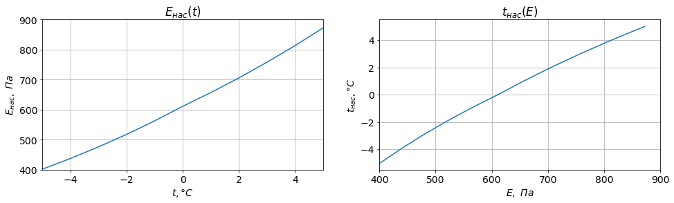

```python
import matplotlib.pyplot as plt  # библиотека для построения графиков
plt.rcParams.update({'font.size': 14})
fig, axes = plt.subplots(1,2, figsize = (16, 4))
#fig.suptitle ("0", fontsize=16)
axes[0].grid(); axes[1].grid()
axes[0].set_xlim(ts_0[0],ts_0[-1])
axes[0].set_ylim(400,900)
axes[0].plot(ts_0, ps_s); axes[1].plot(ps_s, ts_0)
axes[0].set_xlabel('$t, \degree C$'); axes[0].set_ylabel('$E_{нас},\ Па$')
axes[0].set_title('$E_{нас}(t)$'); axes[1].set_title('$t_{нас}(E)$')
axes[1].set_xlim(400,900)
axes[1].set_ylabel('$t_{нас}, \degree C$'); axes[1].set_xlabel('$E,\ Па$');
```

Чем больше влаги содержится в воздухе тем выше потенциал лёдообразования при возникновении благоприятных для этого условий.

$$d = \frac{\mu_{вп} E_{вп}}{\mu_{св} E_{св}} = \frac{\mu_{вп} E_{вп}}{\mu_{св} (p_{атм}-E_{вп})}$$

где $d$ - влагосодержание, кг водяного пара на кг сухого воздуха; $\mu_{вп} = 18$, $\mu_{св} = 29$ - молярная масса водяного пара и сухого воздуха соответственно, г/моль; $E_{вп},\ E_{св}$ - упругость водяного пара и сухого воздуха соответственно, Па; $p_{атм}$ - атмосферное давление, Па.

```python
mu_вп = 18; mu_св = 29; p_атм = 101325
def fd(t, RH):
  """
  Определение влагосодержания воздуха
  t: температура воздуха, С
  RH: относительная влажность воздуха [0; 1]
  return: влагосодержание воздуха, г водяного пара на кг сухого воздуха
  """
  p_s = fE_s(t); p_вп = RH * p_s
  return mu_вп * p_вп / mu_св / (p_атм - p_вп) * 1000.


def ft_тр(t, RH):
  """
  Определение температуры точки росы воздуха
  t: температура воздуха, С
  RH: относительная влажность воздуха [0; 1]
  return: температура точки росы, С
  """
  p_s = fE_s(t); p_вп = RH * p_s
  return ft_s(p_вп)
```

```python
ts_0 = np.linspace(-5, 5, 5)
RHs = np.linspace(0.5, 1., 51)
ds = np.zeros((len(ts_0),len(RHs)))
ds = np.array([[fd(t, RH) for t in ts_0] for RH in RHs])
ts_тр = np.array([[ft_тр(t, RH) for t in ts_0] for RH in RHs])
```

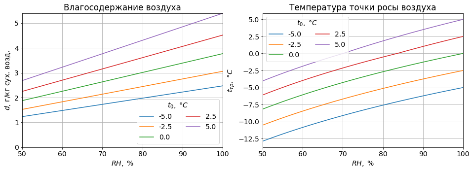

```python
fig, axes = plt.subplots(1,2, figsize = (16, 5))
data =[ds, ts_тр]
axes[0].set_ylim(0, data[0][-1][-1])
for i, ax in enumerate(axes):
  ax.grid(); ax.set_xlim(RHs[0]*100,RHs[-1]*100); ax.set_xlabel('$RH,\ \%$')
  ax.plot(RHs*100, data[i])
  ax.legend(ts_0, ncol=2, title = '$t_0,\ \degree C$')
axes[0].set_ylabel('$d$, г/кг сух. возд.')
axes[1].set_ylabel('$t_{тр},\ \degree C$')
axes[0].set_title('Влагосодержание воздуха')
axes[1].set_title('Температура точки росы воздуха');
```

Для предотвращения образования льда на поверхности входных элементов компрессора ГТУ применяется система подогрева входного воздуха предназначенная для увеличения его температуры до величины гарантирующей, что температура поверхности входных элементов компрессора будет положительной или выше температуры точки росы.

```python
dt_запас = 3  # дополнительный нагрев сверх необходимого по расчёту
dts_нагрев = np.zeros((len(RHs), len(ts_0)))
for j, t in enumerate(ts_0):
  t_пов = ts_0[j] + dt_пов
  #print('Стенка', t_пов)
  for i, RH in enumerate(RHs):
    #print(t_росы)
    if (ts_тр[i,j] + dt_запас) > t_пов and (t_пов - dt_запас) <= 0:
      dts_нагрев[i,j] = ts_тр[i,j] - t_пов + dt_запас
    else:
      dts_нагрев[i,j] = 0.
```

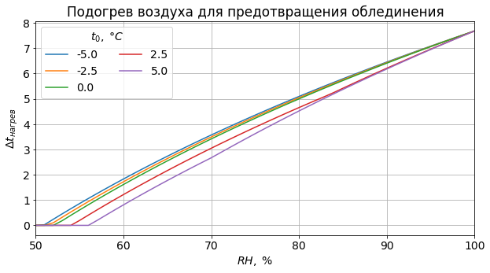

```python
fig, ax = plt.subplots(figsize = (10,5))
ax.grid(); #ax.set_xlim(0.65,); ax.set_ylim(0, 8)
ax.plot(RHs*100, dts_нагрев)
ax.legend(ts_0, ncol=2, title = '$t_0,\ \degree C$')
ax.set_xlim(RHs[0]*100,RHs[-1]*100)
ax.set_xlabel('$RH,\ \%$'); ax.set_ylabel('$\Delta t_{нагрев}$')
ax.set_title('Подогрев воздуха для предотвращения облединения');
```

На верхнем графике видна аномалия --- кривые для температур $-5, -2.5, 0\ ^\circ С$ идут плотно, а затем расстояние между кривыми скачкообразно увеличивается.

Причина данного явления в том, что зависимость упругости водяных паров от температуры для отрицательных и положительных температур воздуха описывается разными формулами. В диапазоне положительных температур при изменении температуры воздуха температура точки росы изменяется медленнее чем в диапазоне отрицательных температур (см. график ниже). Т.к. температрура точки росы при изменении температуры воздуха от 0 до $2.5\ ^\circ С$ возросла на значительно меньшую величину чем при изменении температуры воздуха от $-2.5$ до $0\ ^\circ С$, то нагревать воздух нужно меньше на разницу между двумя этими изменениями.

Изломы на зависимостях начинаются при переходе через $t_{тр} = 0\ ^\circ С$ (хорошо видно на кривой для $t_0 = 5\ ^\circ С$ при $RH=70\%$). При переходе через $t_{тр} = 0\ ^\circ С$ значение температуры мокрого термометра при увеличении значения относительной влажности начинает расти быстрее, а значит начинает быстрее расти величина необходимого подогрева воздуха.

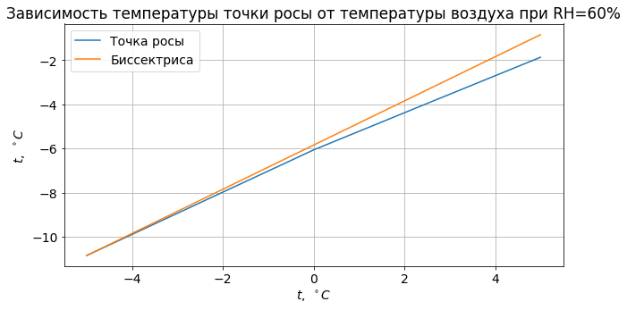

```python
fig, ax = plt.subplots(figsize = (10,5))
ax.set_title('Зависимость температуры точки росы от температуры воздуха при RH=60%')
ax.grid(); #ax.set_xlim(0.65,); ax.set_ylim(0, 8)
indRH = list(RHs).index(0.6)  # индекс элемента со значением 0,6 (RH=60%)
ax.plot(ts_0, ts_тр[indRH][:], label = 'Точка росы')
#ax.plot([ts_0[0], ts_0[-1]],[ts_тр[0][0], ts_тр[0][-1]], label = 'Прямой отрезок')
ax.plot([ts_0[0], ts_0[-1]],[ts_тр[indRH][0],ts_тр[indRH][0] + (ts_0[-1] - ts_0[0])], label = 'Биссектриса')
ax.set_xlabel('$t,\ ^\circ C$'); ax.set_ylabel('$t,\ ^\circ C$')
ax.legend();
```

При нагреве воздуха увеличивается значение упругости насыщенного водяного пара $E_{нас}$, его влагосодержание, а значит и упругость водяного пара $E_{вп}$, не изменяется, значение относительной влажности воздуха $RH = E(t) / E_{нас}(t)$ уменьшается.

#### Ниже осуществлена попытка построить трёхмерный график

```python
t_0 = -5.
E_нас_0 = fE_s(t_0)
dts_нагр = np.linspace(0, 5, 6)
RHs_0 = np.linspace(0.5, 1., 6)
RHs = np.zeros((len(RHs_0), len(dts_нагр)))
dts_нагр_grid, RHs_0_grid = np.meshgrid(dts_нагр, RHs_0)
for j,dt_нагр in enumerate(dts_нагр):
    t = t_0 + dt_нагр
    E_нас = fE_s(t)
    for i,RH_0 in enumerate(RHs_0):
        E_вп = RH_0 * E_нас_0
        RHs[i,j] = E_вп / E_нас
```

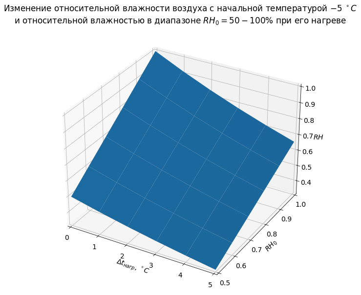

```python
from mpl_toolkits.mplot3d import Axes3D
fig = plt.figure(figsize=(10, 10))
ax_3d = fig.add_subplot(projection='3d')
ax_3d.set_xlabel('$\Delta t_{нагр}$, $^\circ C$'); ax_3d.set_xlim(0., 5.)
ax_3d.set_title('Изменение относительной влажности воздуха с начальной температурой $-5\ ^\circ C$\n'+
                'и относительной влажностью в диапазоне $RH_0 = 50 - 100$% при его нагреве')
ax_3d.set_ylabel('$RH_0$'); ax_3d.set_ylim(0.5, 1.)
ax_3d.set_zlabel('$RH$')
ax_3d.plot_surface(dts_нагр_grid, RHs_0_grid, RHs);
```

### Ссылки

1. СПРАВОЧНОЕ ПОСОБИЕ. Влажный воздух.НП «Инженеры по отоплению, вентиляции, кондиционированию воздуха, теплоснабжению и строительной теплофизике» (НП «АВОК»)

[Инженерные расчёты на Python](https://zen.yandex.ru/id/5f33dcd5554adc5b33aaee83), С.В. Медведев, 2020-2022  
Использование Python и Jupyter Notebook для инженерных расчётов, С.В. Медведев, 2020-2022